# Exploration of Reef Life Survey Dive Sites

10/20/2019

## Dive Surveys

- Long-lasting, cheap and easy to use.
- Common method for collecting data.
- Recreational divers can contribute, allowing more numbers.
- Crucial to assess modern reefs

## The Block Survey

- Divers set out 50 meter “transect” line.
- Count fish 5 meters above and to the side of it.
- Counts fish in a set location for a limited space.
- What are the limitations?

## Reef Life Survey

- Organized by University of Tasmania.
- Aggregates their Reef Survey data.

## Project - At First

- Original goal was to compare surveys by reefs.
- Problems: Most reefs of interest had a low sample size.
- Question: Can we assess the quality of data in different reef sites?

## Analysis - Overview

- Site and Country
- Measurements and Time
- Divers

## Countries with the Highest Survey Numbers

Summary of Most Surveyed Countries

| Country | Earliest Survey | Latest Survey | Number of Surveys | Number of Sites | Average Surveys per Site |
| --- | --- | --- | --- | --- | --- |
| Australia | 2006-02-12 | 2019-08-31 | 10522 | 67 | 157 |
| Spain | 2011-07-19 | 2015-11-19 | 650 | 24 | 27 |
| Panama | 2007-03-19 | 2015-04-10 | 294 | 6 | 49 |
| Indonesia | 2008-06-10 | 2018-03-28 | 283 | 16 | 18 |
| New Zealand | 2008-04-26 | 2018-12-15 | 280 | 12 | 23 |

## Sites grouped by Average Number of Surveys

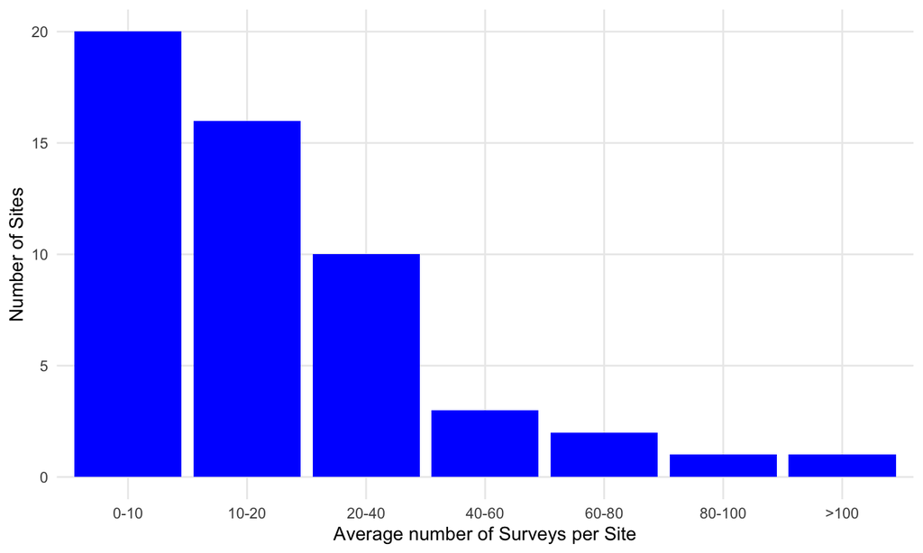

## Countries by Average Surveys Per Site

Countries with Highest Surveys per Site

| Country | Average Surveys per Site | Number of Sites | Number of Surveys |
| --- | --- | --- | --- |
| Australia | 157 | 67 | 10522 |
| Ecuador | 82 | 2 | 164 |
| Costa Rica | 70 | 2 | 139 |
| Nicaragua | 66 | 1 | 66 |
| Panama | 49 | 6 | 294 |

## Rugosity over Time

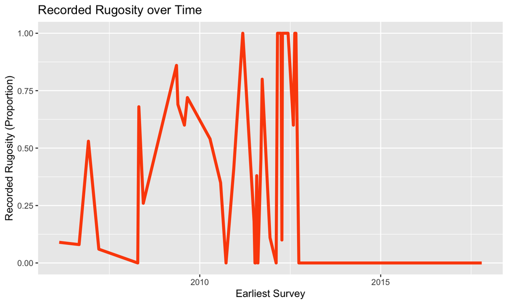

## Visibility over Time

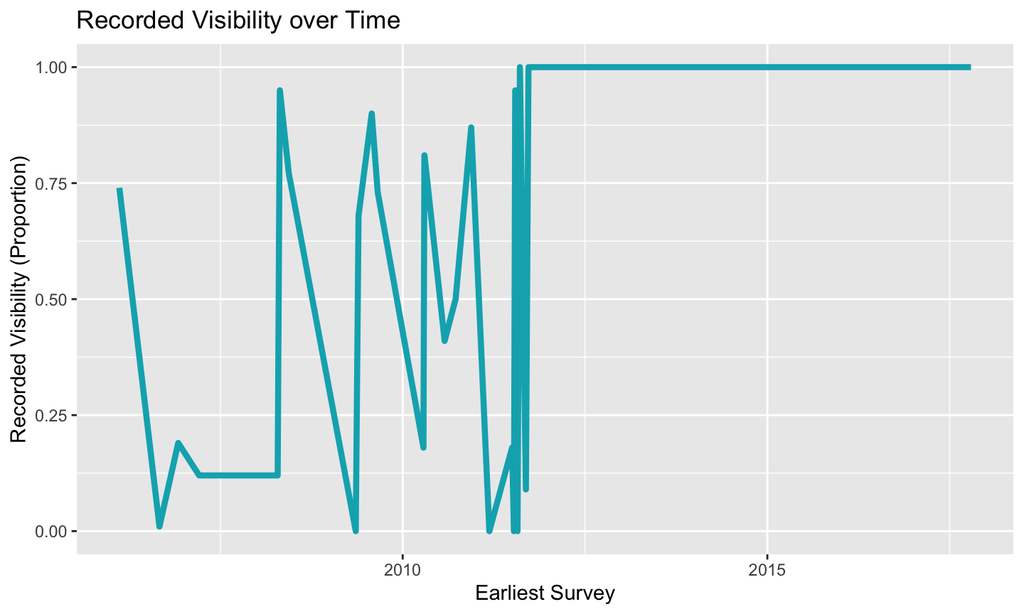

## Most Frequent Divers

Most Active Divers

| Divers | Surveys |
| --- | --- |
| Graham Edgar | 858 |
| Rick Stuart-Smith | 609 |
| James Brook, Sam Owen | 447 |
| Andrew Green | 444 |
| Nicola Davis, Tom Davis | 408 |

## Graham - Proportion of Contribution per Site

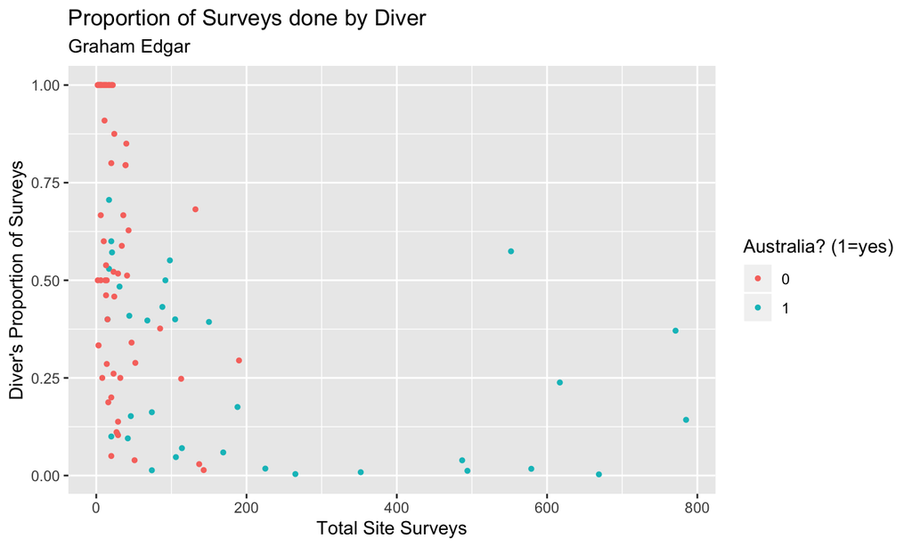

## Without Australia

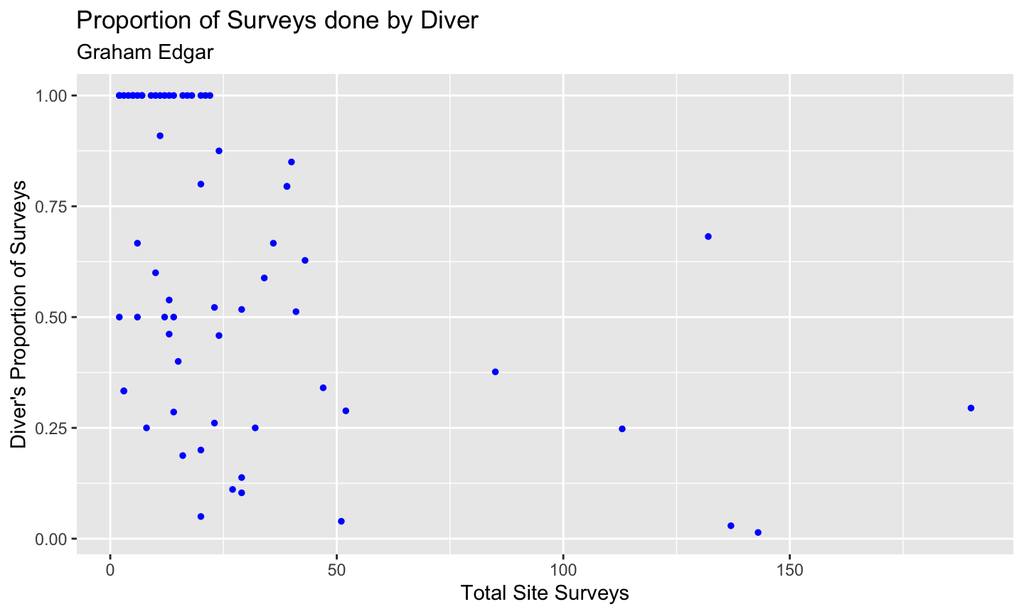

## Summary

- Australia has the most thoroughly recorded data by far.
- Most locations have very low surveys per site.
- A change in methodology may have occurred in 2012.
- Sites with low surveys are vulnerable to diver bias.

## Citations

1. Edgar, GJ and Stuart-Smith, RD, “Systematic global assessment of reef fish communities by the Reef Life Survey program”, Scientific Data, 1 Article 140007. doi:10.1038/sdata.2014.7 ISSN 2052-4463 (2014)